# Cars4U Pricing Case Study

### Context

There is a huge demand for used cars in the Indian Market today. As sales of new cars have slowed down in the recent past, the pre-owned car market has continued to grow over the past years and is larger than the new car market now. Cars4U is a budding tech start-up that aims to find footholes in this market.

In 2018-19, while new car sales were recorded at 3.6 million units, around 4 million second-hand cars were bought and sold. There is a slowdown in new car sales and that could mean that the demand is shifting towards the pre-owned market. In fact, some car sellers replace their old cars with pre-owned cars instead of buying new ones. Unlike new cars, where price and supply are fairly deterministic and managed by OEMs (Original Equipment Manufacturer / except for dealership level discounts which come into play only in the last stage of the customer journey), used cars are very different beasts with huge uncertainty in both pricing and supply. Keeping this in mind, the pricing scheme of these used cars becomes important in order to grow in the market.

## Objective

To answer some of the questions which will help to determine a pricing model that can effectively predict the price of used cars and can help the business in devising profitable strategies using differential pricing.

## Data Description

To explore and visualize the dataset, build a linear regression model to predict the prices of used cars, and generate a set of insights and recommendations that will help the business.

#### Data Dictionary

1. S.No.: Serial number
2. Name: Name of the car which includes brand name and model name
3. Location: Location in which the car is being sold or is available for purchase (cities)
4. Year: Manufacturing year of the car
5. Kilometers_driven: The total kilometers driven in the car by the previous owner(s) in km
6. Fuel_Type: The type of fuel used by the car (Petrol, Diesel, Electric, CNG, LPG)
7. Transmission: The type of transmission used by the car (Automatic/Manual)
8. Owner: Type of ownership
9. Mileage: The standard mileage offered by the car company in kmpl or km/kg
10. Engine: The displacement volume of the engine in CC
11. Power: The maximum power of the engine in bhp
12. Seats: The number of seats in the car
13. New_Price: The price of a new car of the same model in INR Lakhs (1 Lakh INR = 100,000 INR)
14. Price: The price of the used car in INR Lakhs

```python
# Libraries to help with reading and manipulating data
import numpy as np
import pandas as pd

import warnings
warnings.filterwarnings('ignore')   # to avoid warnings

# Libraries to help with data visualization
import matplotlib.pyplot as plt
import seaborn as sns

sns.set()

# Removes the limit for the number of displayed columns
pd.set_option("display.max_columns", None)
# Sets the limit for the number of displayed rows
pd.set_option("display.max_rows", 200)

# to split the data into train and test
from sklearn.model_selection import train_test_split

# to build linear regression_model
from sklearn.linear_model import LinearRegression

# to check model performance
from sklearn.metrics import mean_absolute_error, mean_squared_error, r2_score

#for scaling
from sklearn.preprocessing import StandardScaler, MinMaxScaler

#Libraries for VIF
import statsmodels.api as sm
from statsmodels.stats.outliers_influence import variance_inflation_factor
```

```python
# loading the dataset. Saving the original dataset in a dataframe
original_df = pd.read_csv("used_cars_data.csv", engine="python")
df = original_df.copy()
```

```python
# checking the shape of the data
print(f"There are {df.shape[0]} rows and {df.shape[1]} columns.")  # f-string
```

```
There are 7253 rows and 14 columns.
```

```python
#Check  for dupliucate values
df.duplicated().sum()
print(f"There are {df.duplicated().sum()} duplicate rows.")  # f-string
```

```
There are 0 duplicate rows.
```

```python
# let's view a random sample of the data
df.sample(n=10, random_state=1)
```

|  | S.No. | Name | Location | Year | Kilometers_Driven | Fuel_Type | Transmission | Owner_Type | Mileage | Engine | Power | Seats | New_Price | Price |
| --- | --- | --- | --- | --- | --- | --- | --- | --- | --- | --- | --- | --- | --- | --- |
| 2397 | 2397 | Ford EcoSport 1.5 Petrol Trend | Kolkata | 2016 | 21460 | Petrol | Manual | First | 17.0 kmpl | 1497 CC | 121.36 bhp | 5.0 | 9.47 | 6.00 |
| 3777 | 3777 | Maruti Wagon R VXI 1.2 | Kochi | 2015 | 49818 | Petrol | Manual | First | 21.5 kmpl | 1197 CC | 81.80 bhp | 5.0 | 5.44 | 4.11 |
| 4425 | 4425 | Ford Endeavour 4x2 XLT | Hyderabad | 2007 | 130000 | Diesel | Manual | First | 13.1 kmpl | 2499 CC | 141 bhp | 7.0 | 35.29 | 6.00 |
| 3661 | 3661 | Mercedes-Benz E-Class E250 CDI Avantgrade | Coimbatore | 2016 | 39753 | Diesel | Automatic | First | 13.0 kmpl | 2143 CC | 201.1 bhp | 5.0 | 86.97 | 35.28 |
| 4514 | 4514 | Hyundai Xcent 1.2 Kappa AT SX Option | Kochi | 2016 | 45560 | Petrol | Automatic | First | 16.9 kmpl | 1197 CC | 82 bhp | 5.0 | 8.23 | 6.34 |
| 599 | 599 | Toyota Innova Crysta 2.8 ZX AT | Coimbatore | 2019 | 40674 | Diesel | Automatic | First | 11.36 kmpl | 2755 CC | 171.5 bhp | 7.0 | 28.05 | 24.82 |
| 186 | 186 | Mercedes-Benz E-Class E250 CDI Avantgrade | Bangalore | 2014 | 37382 | Diesel | Automatic | First | 13.0 kmpl | 2143 CC | 201.1 bhp | 5.0 | 86.97 | 32.00 |
| 305 | 305 | Audi A6 2011-2015 2.0 TDI Premium Plus | Kochi | 2014 | 61726 | Diesel | Automatic | First | 17.68 kmpl | 1968 CC | 174.33 bhp | 5.0 | 67.10 | 20.77 |
| 4582 | 4582 | Hyundai i20 1.2 Magna | Kolkata | 2011 | 36000 | Petrol | Manual | First | 18.5 kmpl | 1197 CC | 80 bhp | 5.0 | 10.25 | 2.50 |
| 5434 | 5434 | Honda WR-V Edge Edition i-VTEC S | Kochi | 2019 | 13913 | Petrol | Manual | First | 17.5 kmpl | 1199 CC | 88.7 bhp | 5.0 | 9.36 | 8.20 |

Observation: Mileage, Engine and Power look like columns with a number and a string attached to it. Could look into making them numeric

```python
# Let's look at the statistical summary of the data
df.describe(include="all").T
```

|  | count | unique | top | freq | mean | std | min | 25% | 50% | 75% | max |
| --- | --- | --- | --- | --- | --- | --- | --- | --- | --- | --- | --- |
| S.No. | 7253.0 | NaN | NaN | NaN | 3626.0 | 2093.905084 | 0.0 | 1813.0 | 3626.0 | 5439.0 | 7252.0 |
| Name | 7253 | 2041 | Mahindra XUV500 W8 2WD | 55 | NaN | NaN | NaN | NaN | NaN | NaN | NaN |
| Location | 7253 | 11 | Mumbai | 949 | NaN | NaN | NaN | NaN | NaN | NaN | NaN |
| Year | 7253.0 | NaN | NaN | NaN | 2013.365366 | 3.254421 | 1996.0 | 2011.0 | 2014.0 | 2016.0 | 2019.0 |
| Kilometers_Driven | 7253.0 | NaN | NaN | NaN | 58699.063146 | 84427.720583 | 171.0 | 34000.0 | 53416.0 | 73000.0 | 6500000.0 |
| Fuel_Type | 7253 | 5 | Diesel | 3852 | NaN | NaN | NaN | NaN | NaN | NaN | NaN |
| Transmission | 7253 | 2 | Manual | 5204 | NaN | NaN | NaN | NaN | NaN | NaN | NaN |
| Owner_Type | 7253 | 4 | First | 5952 | NaN | NaN | NaN | NaN | NaN | NaN | NaN |
| Mileage | 7251 | 450 | 17.0 kmpl | 207 | NaN | NaN | NaN | NaN | NaN | NaN | NaN |
| Engine | 7207 | 150 | 1197 CC | 732 | NaN | NaN | NaN | NaN | NaN | NaN | NaN |
| Power | 7078 | 385 | 74 bhp | 280 | NaN | NaN | NaN | NaN | NaN | NaN | NaN |
| Seats | 7200.0 | NaN | NaN | NaN | 5.279722 | 0.81166 | 0.0 | 5.0 | 5.0 | 5.0 | 10.0 |
| New_Price | 7253.0 | NaN | NaN | NaN | 21.307322 | 24.256314 | 3.91 | 7.88 | 11.3 | 21.69 | 375.0 |
| Price | 6019.0 | NaN | NaN | NaN | 9.479468 | 11.187917 | 0.44 | 3.5 | 5.64 | 9.95 | 160.0 |

Observation: Seats has a minimum value of 0, it is not possible for a car to have 0 seats. This looks like an entry error.

### Fixing incorrect entry in Seats data column

```python
#Printing value counts for Seats to take a deeper look
df['Seats'].value_counts()
```

```
5.0     6047
7.0      796
8.0      170
4.0      119
6.0       38
2.0       18
10.0       8
9.0        3
0.0        1
Name: Seats, dtype: int64
```

```python
#Looks like only 1 row has seats as 0. Printing the row where Seats is 0
df[df['Seats'] == 0.0]
```

|  | S.No. | Name | Location | Year | Kilometers_Driven | Fuel_Type | Transmission | Owner_Type | Mileage | Engine | Power | Seats | New_Price | Price |
| --- | --- | --- | --- | --- | --- | --- | --- | --- | --- | --- | --- | --- | --- | --- |
| 3999 | 3999 | Audi A4 3.2 FSI Tiptronic Quattro | Hyderabad | 2012 | 125000 | Petrol | Automatic | First | 10.5 kmpl | 3197 CC | NaN | 0.0 | 53.14 | 18.0 |

Observation:Some research indicates that 2012 Audi A4 3.3 Quattro has 5 seats. So this row can be updated to fix that error.

```python
#Update the value for Seats where it is 0 to 5 for Audi A4 3.2
df.loc[df['Seats'] == 0.0, 'Seats'] = 5.0
```

```python
#Checking Value counts again to ensure the 0 value is not there and the count for 5 increased by 1
df['Seats'].value_counts()
```

```
5.0     6048
7.0      796
8.0      170
4.0      119
6.0       38
2.0       18
10.0       8
9.0        3
Name: Seats, dtype: int64
```

## Looking at datatypes

```python
# checking column datatypes
df.info()
```

```
<class 'pandas.core.frame.DataFrame'>
RangeIndex: 7253 entries, 0 to 7252
Data columns (total 14 columns):
 #   Column             Non-Null Count  Dtype
---  ------             --------------  -----
 0   S.No.              7253 non-null   int64
 1   Name               7253 non-null   object
 2   Location           7253 non-null   object
 3   Year               7253 non-null   int64
 4   Kilometers_Driven  7253 non-null   int64
 5   Fuel_Type          7253 non-null   object
 6   Transmission       7253 non-null   object
 7   Owner_Type         7253 non-null   object
 8   Mileage            7251 non-null   object
 9   Engine             7207 non-null   object
 10  Power              7078 non-null   object
 11  Seats              7200 non-null   float64
 12  New_Price          7253 non-null   float64
 13  Price              6019 non-null   float64
dtypes: float64(3), int64(3), object(8)
memory usage: 793.4+ KB
```

Observation: There are 14 columns. S.No., Year and Kilometers_Driven are int64.Seats, New_Price, Price are float64. Name, Location, Fuel_type, Transmission, Owner_type, Mileage, Engine, Power are of object data type.

We can print unique values of each column to see if some of them are good candidates for 'category' data type. If the unique values are less than 15 and it is of category data type then we can change it.

Also S.No. looks like an index number which we can drop as its not needed since its just a unique identifier

Name can also be dropped but we will drop it later as we might need it for data analysis.

There are quite a few nulls especially in the Price column, we will look at them closely.

Mileage has only 2 rows that are null so we will drop those two rows.

```python
#The S.No. column can be dropped
df.drop(['S.No.'],axis=1,inplace=True)
```

```python
#Dropping the 2 rows where Mileage is null, since there are only 2 null rows we can deal with them here
df = df.drop(df.index[df['Mileage'].isnull()])
```

## Univariate analysis

### Basic summary statistics and consequences

```python
# Let's look at the statistical summary of the data
df.describe().T
```

|  | count | mean | std | min | 25% | 50% | 75% | max |
| --- | --- | --- | --- | --- | --- | --- | --- | --- |
| Year | 7251.0 | 2013.365329 | 3.254604 | 1996.00 | 2011.00 | 2014.00 | 2016.000 | 2019.0 |
| Kilometers_Driven | 7251.0 | 58702.290029 | 84439.126646 | 171.00 | 34000.00 | 53442.00 | 73000.000 | 6500000.0 |
| Seats | 7198.0 | 5.280495 | 0.809376 | 2.00 | 5.00 | 5.00 | 5.000 | 10.0 |
| New_Price | 7251.0 | 21.308015 | 24.259469 | 3.91 | 7.88 | 11.30 | 21.535 | 375.0 |
| Price | 6017.0 | 9.478340 | 11.189605 | 0.44 | 3.50 | 5.64 | 9.950 | 160.0 |

Observations: Year: is slightly left skewed. Kilometers_Driven, Price and New_Price are right skewed Seats is normally distributed. Kilometers_Driven, New_Price and Price values are spread over a large range. Kilometers_Driven has a large standard deviation. The maximum of Kilometers_Driven is 6.5 million km, this looks like an error. we can look at it a bit closer.

```python
# function to plot a boxplot and a histogram along the same scale.


def histogram_boxplot(data, feature, figsize=(12, 7), kde=False, bins=None):
    """
    Boxplot and histogram combined

    data: dataframe
    feature: dataframe column
    figsize: size of figure (default (12,7))
    kde: whether to the show density curve (default False)
    bins: number of bins for histogram (default None)
    """
    f2, (ax_box2, ax_hist2) = plt.subplots(
        nrows=2,  # Number of rows of the subplot grid= 2
        sharex=True,  # x-axis will be shared among all subplots
        gridspec_kw={"height_ratios": (0.25, 0.75)},
        figsize=figsize,
    )  # creating the 2 subplots
    sns.boxplot(
        data=data, x=feature, ax=ax_box2, showmeans=True, color="violet"
    )  # boxplot will be created and a star will indicate the mean value of the column
    sns.histplot(
        data=data, x=feature, kde=kde, ax=ax_hist2, bins=bins, palette="winter"
    ) if bins else sns.histplot(
        data=data, x=feature, kde=kde, ax=ax_hist2
    )  # For histogram
    ax_hist2.axvline(
        data[feature].mean(), color="green", linestyle="--"
    )  # Add mean to the histogram
    ax_hist2.axvline(
        data[feature].median(), color="black", linestyle="-"
    )  # Add median to the histogram
```

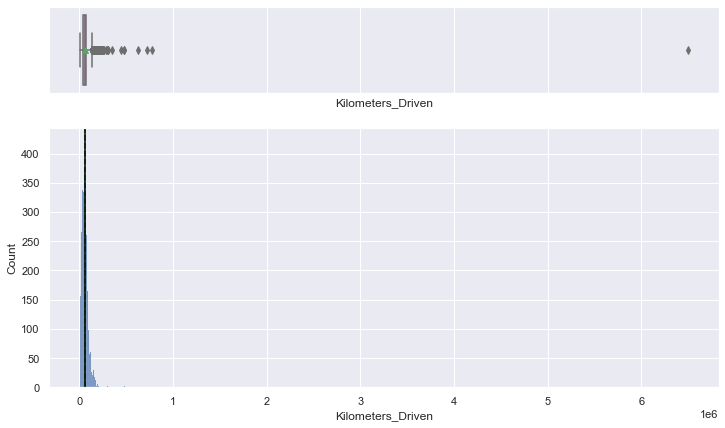

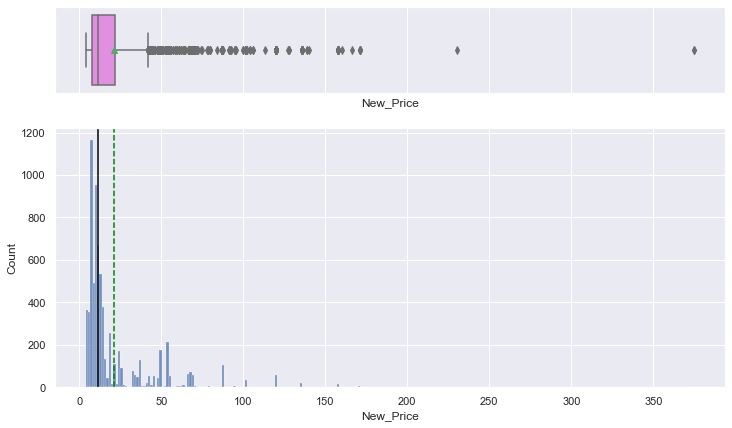

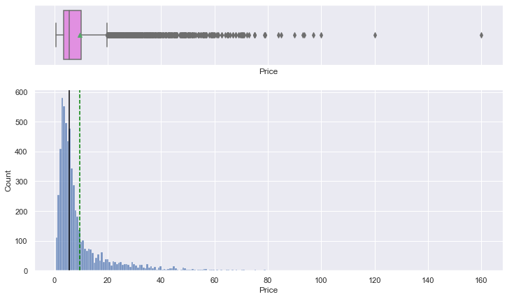

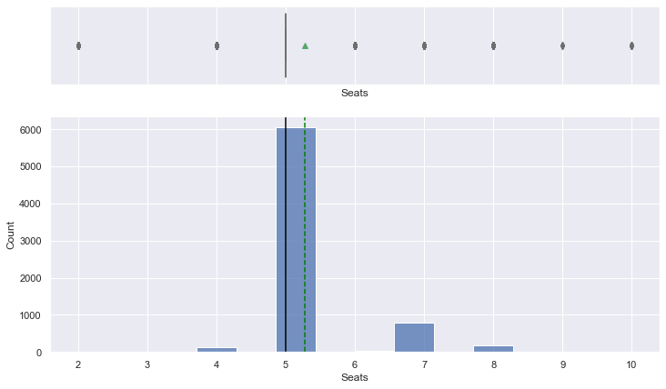

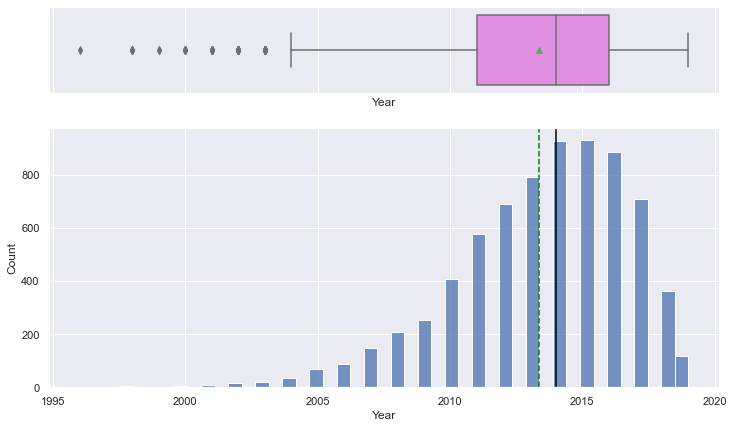

```python
#For every column in the dataframe that has a numerical datatype, show histogram and box plot
for colname in (df.columns[df.dtypes == 'int64'] | df.columns[df.dtypes == 'float64']):
    histogram_boxplot(df, colname)
```

Observation: Kilometers is highly right skewed and has many outliers and a wide distribution.

Price and New_Price are also rightly skewed with a wide range.

Seats has more of a steep normal distribution, with most cars having 5 seats.

Year has a slightly left skewed distribution.

## Looking at non numerical variable analysis

```python
# function to create labeled barplots
#This function will show barplot only if the unique column values are less than 20


def labeled_barplot(data, feature, perc=False, n=None):
    """
    Barplot with percentage at the top

    data: dataframe
    feature: dataframe column
    perc: whether to display percentages instead of count (default is False)
    n: displays the top n category levels (default is None, i.e., display all levels)
    """

    total = len(data[feature])  # length of the column
    count = data[feature].nunique()
    if count < 20 :
        if n is None:
            plt.figure(figsize=(count + 1, 5))
        else:
            plt.figure(figsize=(n + 1, 5))

        plt.xticks(rotation=90, fontsize=15)
        ax = sns.countplot(
            data=data,
            x=feature,
            palette="Paired",
            order=data[feature].value_counts().index[:n].sort_values(),
        )

        for p in ax.patches:
            if perc == True:
                label = "{:.1f}%".format(
                    100 * p.get_height() / total
                )  # percentage of each class of the category
            else:
                label = p.get_height()  # count of each level of the category

            x = p.get_x() + p.get_width() / 2  # width of the plot
            y = p.get_height()  # height of the plot

            ax.annotate(
                label,
                (x, y),
                ha="center",
                va="center",
                size=12,
                xytext=(0, 5),
                textcoords="offset points",
            )  # annotate the percentage

        plt.show()  # show the plot
    else:
        print(f"The {feature} column has more than 20 unique values so will be skipped")  # f-string
```

```
The Name column has more than 20 unique values so will be skipped
```

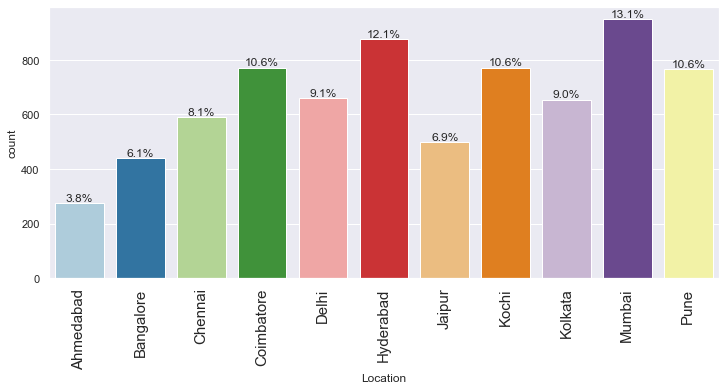

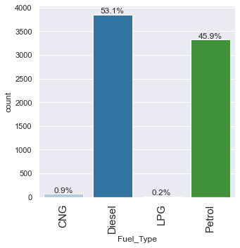

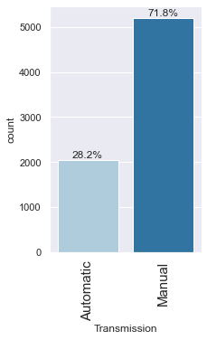

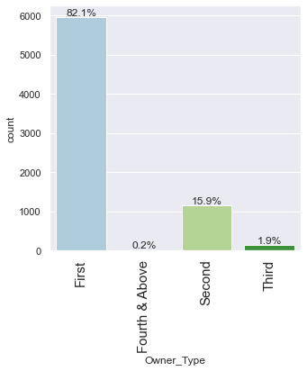

```
The Mileage column has more than 20 unique values so will be skipped
The Engine column has more than 20 unique values so will be skipped
The Power column has more than 20 unique values so will be skipped
```

```python
#For every column in the dataframe that has a categorical or object datatype, show distribution plot
#The unique values will be shown only if they are less than 20
for colname in df.columns[df.dtypes == 'category'] | df.columns[df.dtypes == 'object']:
    labeled_barplot(df, colname, perc=True)
```

Observation: Most of the cars, around 13% of the cars are from Mumbai, then Hyderabad, followed by Kochi and Coimbatore. Ahmedabad has the least number of cars.

Diesel is the most common fuel_type with more than half the cars (53%) being Diesel, then Petrol with 45.9 % of the cars being run with petrol. CNG is 0.9% and LPG cars are only 0.2%

Most of the cars have a Manual Transmission (72%).

The most common Owner_type is First then followed by Second.

```python
#Print the unique values for each column
for i in df.columns:
    n = len(pd.unique(df[i]))
    print (i, n)
```

```
Name 2039
Location 11
Year 23
Kilometers_Driven 3660
Fuel_Type 4
Transmission 2
Owner_Type 4
Mileage 450
Engine 150
Power 385
Seats 9
New_Price 643
Price 1374
```

Obervation: We can look at columns that have fewer then 15 unique values and see if they will be good candidates to change to category datatype.

```python
#Printing Value_counts for columns who have less than or equal to 15 unique values
#m = maximum number of unique values that we will look at
m=15
for i in df.columns:
    n = len(pd.unique(df[i]))

    if n <= m:
        print (df[i].value_counts())
        print('')
```

```
Mumbai        948
Hyderabad     876
Coimbatore    772
Kochi         772
Pune          765
Delhi         660
Kolkata       654
Chennai       590
Jaipur        499
Bangalore     440
Ahmedabad     275
Name: Location, dtype: int64

Diesel    3852
Petrol    3325
CNG         62
LPG         12
Name: Fuel_Type, dtype: int64

Manual       5204
Automatic    2047
Name: Transmission, dtype: int64

First             5950
Second            1152
Third              137
Fourth & Above      12
Name: Owner_Type, dtype: int64

5.0     6046
7.0      796
8.0      170
4.0      119
6.0       38
2.0       18
10.0       8
9.0        3
Name: Seats, dtype: int64
```

Observation: The value_counts have also revealed similar observations as were noted in the univariate analysis above.

## Feature Engineering

```python
#Fuel_Type, Transmission, Owner_Type and Location look like good candidates for category data type
#Changing datatypes to category instead of object for Fuel_Type, Transmission, Owner_Type, Location
df.Fuel_Type = df.Fuel_Type.astype('category')
df.Transmission = df.Transmission.astype('category')
df.Owner_Type = df.Owner_Type.astype('category')
df.Location = df.Location.astype('category')
```

```python
#Engine can be an int data type instead of object data type.
#From the data it looks like a 'CC' is appended to a numerical engine type value
df['Engine'].value_counts()
eng = df["Engine"].str.split(" ", n = 1, expand = True)
eng[1].value_counts()
```

```
CC    7205
Name: 1, dtype: int64
```

```python
#Loop through Engine Column and split the column between the first numbers and last 2 'CC' characters
#Store the first part into a list. If it is null then put a 0 since a car cannot have Engine value as 0 it looks safe
#to make this assumption. we can deal with nulls after making this column numeric
Correct_Engine= []
for i in df.Engine:
    if str(i).endswith('CC'):
        i = i[:-3]
        Correct_Engine.append(int(i))
    else:
        Correct_Engine.append(0)
```

```python
#Checking if data looks good
#Update the Engine column with the Correct Engine value
df['Engine']=Correct_Engine
df['Engine'].value_counts()
```

```
1197    732
1248    610
1498    370
998     309
1198    281
2179    278
1497    273
1968    266
1995    212
1461    188
2143    184
1199    177
1582    174
1396    170
796     164
```

[output cut: 136 more lines]

```python
#Convert Engine data type from object to int
df.Engine = df.Engine.astype(int)
```

```python
#Power can be a float data type instead of object data type.
#From the data it looks like a 'bhp' is appended to a numerical power type value
df['Power'].value_counts()
pwr = df["Power"].str.split(" ", n = 1, expand = True)
pwr[1].value_counts()
```

```
bhp    7076
Name: 1, dtype: int64
```

```python
#Loop through Power Column and split the column between the first numbers and last 3 'bhp' characters
#Store the first part into a list. If it is null then put a 0. Since a car cannot have the Power value as 0 it looks safe
#to make this assumption. we can deal with nulls after making this column numeric
Correct_Pwr= []
for i in df.Power:
    if str(i).endswith('bhp'):
        i = i[:-4]
        Correct_Pwr.append(float(i))
    else:
        Correct_Pwr.append(0)
```

```python
#Checking if data looks good
#Update the Power column with the Correct Power value
df['Power']=Correct_Pwr
df['Power'].value_counts()

#Convert Power data type from object to int
df.Power = df.Power.astype(float)
```

```python
df['Power'].value_counts()
```

```
74.00     280
0.00      175
98.60     166
73.90     152
140.00    142
         ...
421.00      1
89.75       1
387.30      1
226.60      1
241.60      1
Name: Power, Length: 383, dtype: int64
```

```python
#Mileage can be a float data type
#In the data it looks like mileage is a number with either kmpl or km/kg attached to it
#we can split Mileage and save the numeric part. We will not be needing any coversion since both units measure in km or kl
mlg = df["Mileage"].str.split(" ", n = 1, expand = True)
mlg[1].value_counts()
```

```
kmpl     7177
km/kg      74
Name: 1, dtype: int64
```

Observation: There are 7,177 rows that have mileage in kmpl and 74 rows that have mileage in km/kg

```python
#If the Mileage endswith km/kg then trim 'km/kg' and store the number in Mileage column
#If the Mileage endswith kmpl then trim 'kmpl' and store the number in Mileage column
#Since we dropped the 2 null values in Mileage earlier, we dont have to deal with nulls as we know there are no
#nulls anymore

Correct_Mileage= []
for i in df.Mileage:
    if str(i).endswith('km/kg'):
        i = i[:-6]
        Correct_Mileage.append(float(i))
    elif str(i).endswith('kmpl'):
        i = i[:-6]
        Correct_Mileage.append(float(i))
```

```python
#Update the Mileage column
df['Mileage']=Correct_Mileage

#Convert Mileage data type from object to int
df.Mileage = df.Mileage.astype(float)
```

### Looking at Missing values

```python
# Checking columns for missing values
df.isnull().sum().sort_values(ascending=False)
```

```
Price                1234
Seats                  53
Name                    0
Location                0
Year                    0
Kilometers_Driven       0
Fuel_Type               0
Transmission            0
Owner_Type              0
Mileage                 0
Engine                  0
Power                   0
New_Price               0
dtype: int64
```

Observation:

1. Price has 1,234 null rows
2. Seats has 53 null rows

Earlier we noticed that Engine and Power also have null values. They are not showing here because we changed the nulls to zeroes. We will look at them seperately below. We already dropped the two nulls in Mileage.

Price has a lot of null rows. We would need to fix this to get better model performance since it is the target variable.

```python
#Looking at sample data where Price is null
df[df['Price'].isnull()]
```

|  | Name | Location | Year | Kilometers_Driven | Fuel_Type | Transmission | Owner_Type | Mileage | Engine | Power | Seats | New_Price | Price |
| --- | --- | --- | --- | --- | --- | --- | --- | --- | --- | --- | --- | --- | --- |
| 6019 | Maruti Alto K10 LXI CNG | Delhi | 2014 | 40929 | CNG | Manual | First | 32.26 | 998 | 58.20 | 4.0 | 4.360 | NaN |
| 6020 | Maruti Alto 800 2016-2019 LXI | Coimbatore | 2013 | 54493 | Petrol | Manual | Second | 24.00 | 796 | 47.30 | 5.0 | 4.360 | NaN |
| 6021 | Toyota Innova Crysta Touring Sport 2.4 MT | Mumbai | 2017 | 34000 | Diesel | Manual | First | 13.60 | 2393 | 147.80 | 7.0 | 25.270 | NaN |
| 6022 | Toyota Etios Liva GD | Hyderabad | 2012 | 139000 | Diesel | Manual | First | 23.50 | 1364 | 0.00 | 5.0 | 8.525 | NaN |
| 6023 | Hyundai i20 Magna | Mumbai | 2014 | 29000 | Petrol | Manual | First | 18.00 | 1197 | 82.85 | 5.0 | 10.250 | NaN |
| ... | ... | ... | ... | ... | ... | ... | ... | ... | ... | ... | ... | ... | ... |
| 7248 | Volkswagen Vento Diesel Trendline | Hyderabad | 2011 | 89411 | Diesel | Manual | First | 20.50 | 1598 | 103.60 | 5.0 | 13.230 | NaN |
| 7249 | Volkswagen Polo GT TSI | Mumbai | 2015 | 59000 | Petrol | Automatic | First | 17.20 | 1197 | 103.60 | 5.0 | 10.150 | NaN |
| 7250 | Nissan Micra Diesel XV | Kolkata | 2012 | 28000 | Diesel | Manual | First | 23.00 | 1461 | 63.10 | 5.0 | 9.470 | NaN |
| 7251 | Volkswagen Polo GT TSI | Pune | 2013 | 52262 | Petrol | Automatic | Third | 17.00 | 1197 | 103.60 | 5.0 | 10.150 | NaN |
| 7252 | Mercedes-Benz E-Class 2009-2013 E 220 CDI Avan... | Kochi | 2014 | 72443 | Diesel | Automatic | First | 10.00 | 2148 | 170.00 | 5.0 | 86.970 | NaN |

1234 rows × 13 columns

```python
#If we drop the rows where Price is null, we can see if the other null values are also taken care of.
#We have already updated the null values for Engine and Power to 0

df = df.drop(df.index[df['Price'].isnull()])
```

```python
#Power is not showing because we changed the null values to 0 when we made the column numeric above
#Analyzing the Power column that has 0 for nulls

(df['Power'] == 0).sum()
```

```
143
```

Observation:Power still has null values (which are set to 0 ) lets see how to handle them.

```python
df['Power'].describe().T
```

```
count    6017.000000
mean      110.580176
std        55.956056
min         0.000000
25%        74.000000
50%        91.100000
75%       138.030000
max       560.000000
Name: Power, dtype: float64
```

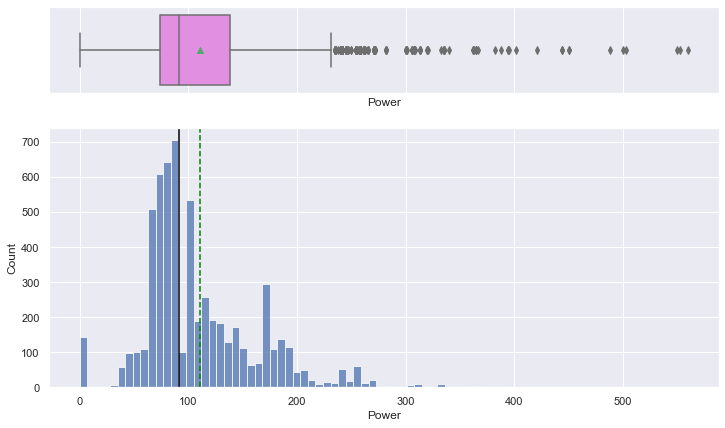

```python
histogram_boxplot(df, 'Power')
```

Observation: Power is right skewed. It has many outliers and a wide range, so for null values maybe we could populate it with the median instead of the mean

```python
df['Power'].median()
```

```
91.1
```

```python
#Update the value for Power where it is 0 to the median
df.loc[df['Power'] == 0.0, 'Power'] = df['Power'].median()
```

```python
#Checking to see if Power has any 0 values
(df['Power'] == 0).sum()
```

```
0
```

```python
#Analyzing the Seats column
#Looking at data where Seats is null
df['Seats'].isnull().sum()
```

```
42
```

```python
#In the univariate analysis we saw that Seats is normally distributed so we could use the mean
#of Seats to update the null values

#Update the value for Seats where it is 0 to the mean
df.loc[df['Seats'].isnull(), 'Seats'] = df['Seats'].mean()

#Since cars can only have seats as integers not decimals we will convert Seats data type from float to int
df.Seats = df.Seats.astype(int)
```

```python
#we noticed earlier that Mileage is normally distributed so the rows that have Mileage as 0 can be imputed to the mean
df.loc[df['Mileage'] == 0.0, 'Mileage'] = df['Mileage'].mean()
```

[output not shown]

```python
#Checking to see if Engine has any 0 values
(df['Engine'] == 0).sum()
```

```
36
```

```python
#There are rows where Engine is 0 we can update that to the median as this column is rightly skewed.
#Update the value for Engine where it is 0 to the median
df.loc[df['Engine']== 0, 'Engine'] = df['Engine'].median()
```

```python
df.isnull().sum().sort_values(ascending=False)
```

```
Name                 0
Location             0
Year                 0
Kilometers_Driven    0
Fuel_Type            0
Transmission         0
Owner_Type           0
Mileage              0
Engine               0
Power                0
Seats                0
New_Price            0
Price                0
dtype: int64
```

Observation: we do not have any nulls

## Bivariate Analysis

### Looking at the relationship between numerical variables using pair plots and heat map

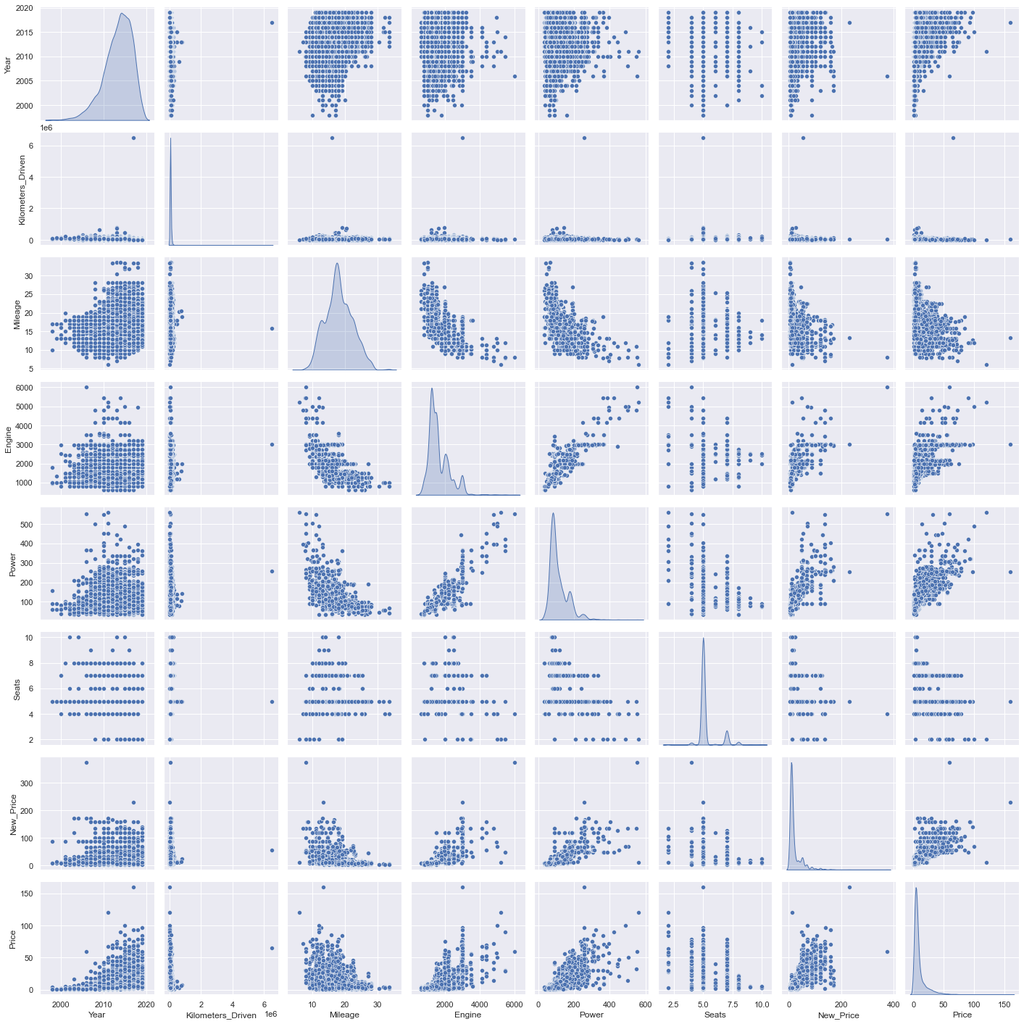

```python
sns.pairplot(df, diag_kind="kde")
```

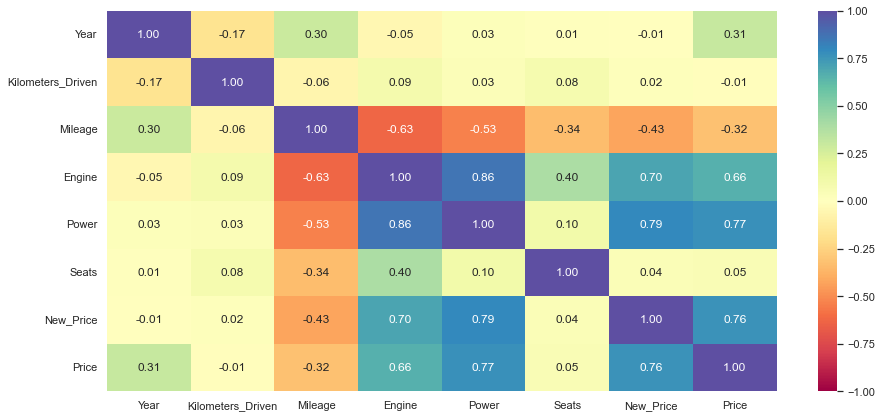

```python
correlation = df.corr()
plt.figure(figsize=(15, 7))
sns.heatmap(correlation, annot=True, vmin=-1, vmax=1, fmt=".2f", cmap="Spectral")
plt.show()
```

Power is also highly corelated with Price, New_price, Engine and negatively corelated to Mileage.

At first glance, it looks like we should drop some of these highly corelated columns. However later on we will calculate the variance Inflation Factor (VIF). This is another way to measure colinearility between columns keeping all columns in mind. The VIF factor for these columns is less than 10, therefore, these will not be dropped

## Let's check the variation in price with some of the categorical columns in our data

```python
def category_boxplot(data, feature, figsize=(12, 7), kde=False, bins=None):
    """
    Boxplot with y as Price

    data: dataframe
    feature: dataframe column
    figsize: size of figure (default (12,7))
    kde: whether to the show density curve (default False)
    bins: number of bins for histogram (default None)
    """
    plt.figure(figsize=figsize)
    sns.boxplot(x=feature, y="Price", data=df)
    plt.show()
```

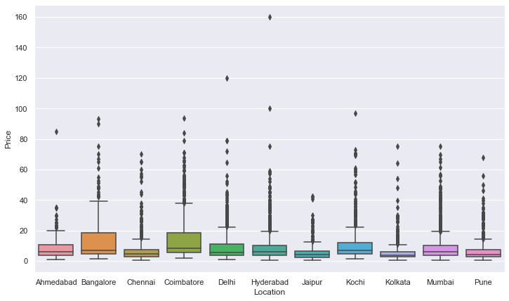

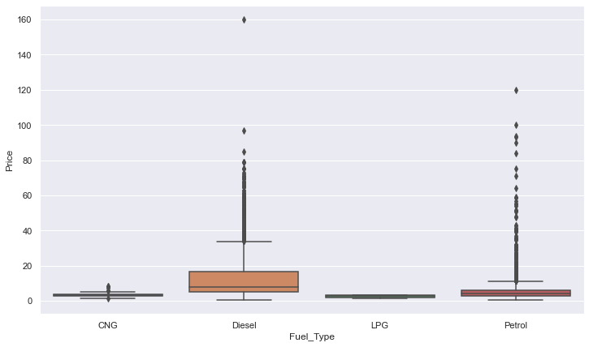

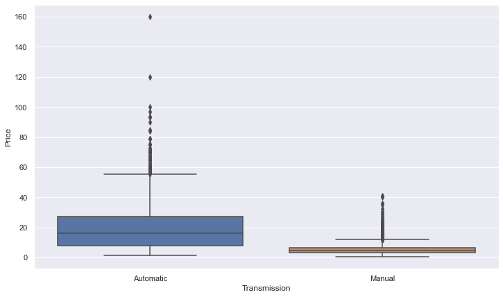

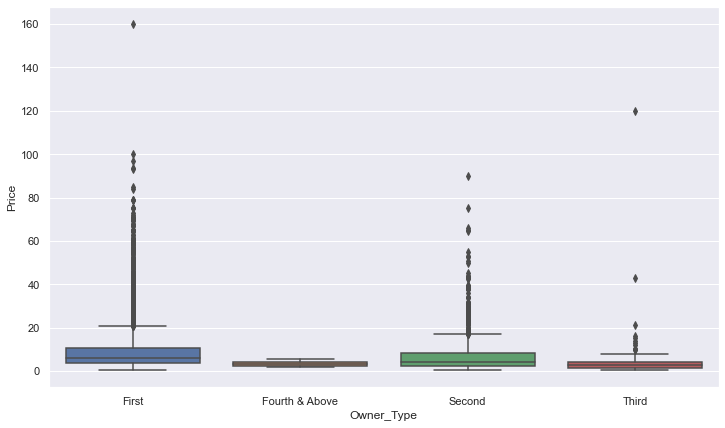

```python
#For every category column print a boxplot with category and price to see how they are related.
for colname in (df.columns[df.dtypes == 'category']):
    category_boxplot(df, colname)
```

Observation: Locations of Kolakata, Jaipur, Pune and Chennai have lower Price. Locations of Coimbatore and Bangalore have a higher car price.

CNG and LPG have a lower price. Between Petrol and Diesel, Diesel has a higher price.

Automatic cars have a higher price than manual transmission cars.

## Outlier Treatments

```python
# Let's look at the statistical summary of the data
df.describe().T
```

|  | count | mean | std | min | 25% | 50% | 75% | max |
| --- | --- | --- | --- | --- | --- | --- | --- | --- |
| Year | 6017.0 | 2013.358152 | 3.269967 | 1998.00 | 2011.00 | 2014.00 | 2016.00 | 2019.00 |
| Kilometers_Driven | 6017.0 | 58742.282034 | 91283.745583 | 171.00 | 34000.00 | 53000.00 | 73000.00 | 6500000.00 |
| Mileage | 6017.0 | 18.084958 | 4.168479 | 6.00 | 15.00 | 18.00 | 21.00 | 33.54 |
| Engine | 6017.0 | 1620.737078 | 599.398319 | 624.00 | 1198.00 | 1493.00 | 1969.00 | 5998.00 |
| Power | 6017.0 | 112.745258 | 53.336233 | 34.20 | 78.00 | 91.10 | 138.03 | 560.00 |
| Seats | 6017.0 | 5.277713 | 0.803597 | 2.00 | 5.00 | 5.00 | 5.00 | 10.00 |
| New_Price | 6017.0 | 21.500754 | 24.336731 | 3.91 | 7.88 | 11.30 | 21.77 | 375.00 |
| Price | 6017.0 | 9.478340 | 11.189605 | 0.44 | 3.50 | 5.64 | 9.95 | 160.00 |

```python
def num_boxplot(data, feature, figsize=(12, 7), kde=False, bins=None):
    """
    Boxplot for numeric columns

    data: dataframe
    feature: dataframe column
    figsize: size of figure (default (12,7))
    kde: whether to the show density curve (default False)
    bins: number of bins for histogram (default None)
    """
    plt.figure(figsize=figsize)
    sns.boxplot(x=feature, data=df)
    plt.show()
```

```python
df.info()
```

```
<class 'pandas.core.frame.DataFrame'>
Int64Index: 6017 entries, 0 to 6018
Data columns (total 13 columns):
 #   Column             Non-Null Count  Dtype
---  ------             --------------  -----
 0   Name               6017 non-null   object
 1   Location           6017 non-null   category
 2   Year               6017 non-null   int64
 3   Kilometers_Driven  6017 non-null   int64
 4   Fuel_Type          6017 non-null   category
 5   Transmission       6017 non-null   category
 6   Owner_Type         6017 non-null   category
 7   Mileage            6017 non-null   float64
 8   Engine             6017 non-null   int32
 9   Power              6017 non-null   float64
 10  Seats              6017 non-null   int32
 11  New_Price          6017 non-null   float64
 12  Price              6017 non-null   float64
dtypes: category(4), float64(4), int32(2), int64(2), object(1)
memory usage: 576.5+ KB
```

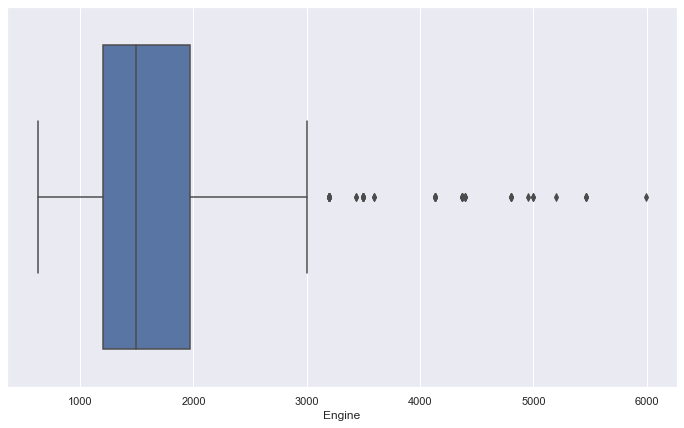

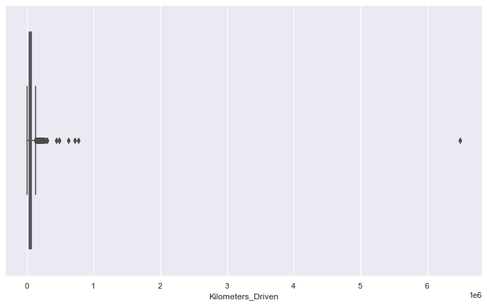

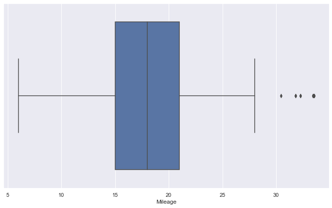

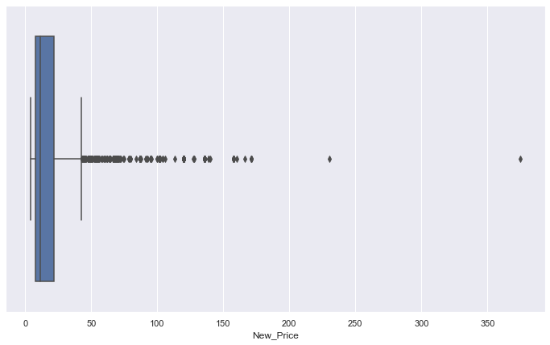

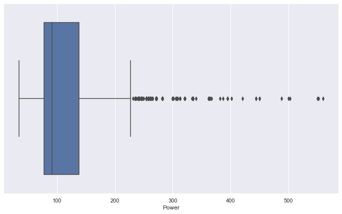

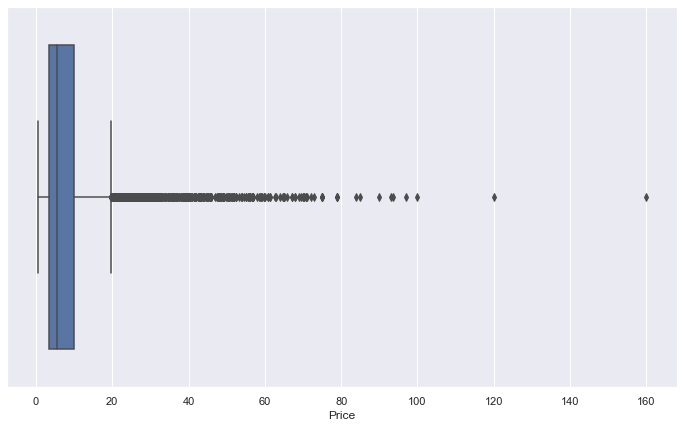

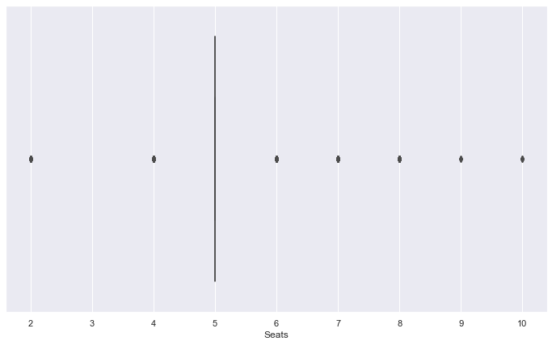

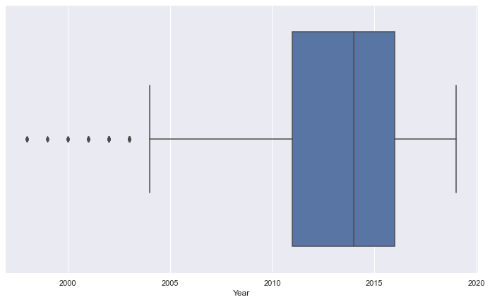

```python
#For every column in the dataframe that has a numerical datatype, show a box plot
for colname in (df.columns[df.dtypes == 'int'] | df.columns[df.dtypes == 'float'] | df.columns[df.dtypes == 'int64'] ):
    num_boxplot(df, colname)
```

Engine is slightly right skewed.

Kilometers_Driven is highly positively skewed and has one large outlier. We would have to look at this closely.

Mileage is normally distributed with a few points outside the whisker.

Price and New_Price are also right skewed and have many points outside the whiskers, we can look at them closely

Power is rightly skewed and has few points that are outside the whiskers. But this could be normal since cars can have wide range of power

For Seats the most common value is 5, with a few data points between 2 and 10.

```python
#Looking at data to see cars that have a high Power makes sense
df.sort_values('Power', ascending=False)
```

|  | Name | Location | Year | Kilometers_Driven | Fuel_Type | Transmission | Owner_Type | Mileage | Engine | Power | Seats | New_Price | Price |
| --- | --- | --- | --- | --- | --- | --- | --- | --- | --- | --- | --- | --- | --- |
| 5781 | Lamborghini Gallardo Coupe | Delhi | 2011 | 6500 | Petrol | Automatic | Third | 6.0 | 5204 | 560.0 | 2 | 11.300 | 120.00 |
| 5521 | Bentley Continental Flying Spur | Hyderabad | 2006 | 48000 | Petrol | Automatic | First | 8.0 | 5998 | 552.0 | 4 | 375.000 | 59.00 |
| 2100 | Porsche Cayenne Turbo S | Mumbai | 2010 | 35000 | Petrol | Automatic | Second | 11.0 | 4806 | 550.0 | 5 | 136.000 | 32.00 |
| 5088 | Jaguar XJ 5.0 L V8 Supercharged | Coimbatore | 2011 | 43686 | Petrol | Automatic | First | 10.0 | 5000 | 503.0 | 4 | 69.675 | 50.66 |
| 70 | Porsche Cayenne 2009-2014 Turbo | Mumbai | 2008 | 73000 | Petrol | Automatic | First | 8.0 | 4806 | 500.0 | 5 | 136.000 | 14.50 |
| ... | ... | ... | ... | ... | ... | ... | ... | ... | ... | ... | ... | ... | ... |
| 1912 | Maruti Omni E MPI STD BS IV | Mumbai | 2013 | 11734 | Petrol | Manual | First | 16.0 | 796 | 34.2 | 8 | 7.880 | 2.25 |
| 2849 | Maruti Omni MPI CARGO BSIV | Kolkata | 2015 | 23000 | Petrol | Manual | First | 16.0 | 796 | 34.2 | 5 | 7.880 | 1.50 |
| 1008 | Maruti Omni E MPI STD BS IV | Kochi | 2019 | 11571 | Petrol | Manual | First | 16.0 | 796 | 34.2 | 8 | 7.880 | 3.80 |
| 2196 | Maruti Omni MPI STD BSIV | Coimbatore | 2017 | 15473 | Petrol | Manual | First | 16.0 | 796 | 34.2 | 5 | 7.880 | 3.58 |
| 790 | Maruti Omni E 8 Str STD | Hyderabad | 2013 | 26875 | Petrol | Manual | First | 16.0 | 796 | 34.2 | 8 | 7.880 | 2.35 |

6017 rows × 13 columns

Looking at the data we can see that cars like Lamborghini, Bentley and Porsche have a higher Power of around 500 and cars like Maruti and others have lower Power. This makes sense and we see that the outliers for Power are natural. So we will not do anything further.

```python
#Looking at Kilometers_Driven to check for outliers
df.sort_values('Kilometers_Driven', ascending=False)
```

|  | Name | Location | Year | Kilometers_Driven | Fuel_Type | Transmission | Owner_Type | Mileage | Engine | Power | Seats | New_Price | Price |
| --- | --- | --- | --- | --- | --- | --- | --- | --- | --- | --- | --- | --- | --- |
| 2328 | BMW X5 xDrive 30d M Sport | Chennai | 2017 | 6500000 | Diesel | Automatic | First | 15.9 | 2993 | 258.00 | 5 | 55.07 | 65.00 |
| 340 | Skoda Octavia Ambition Plus 2.0 TDI AT | Kolkata | 2013 | 775000 | Diesel | Automatic | First | 19.0 | 1968 | 141.00 | 5 | 25.83 | 7.50 |
| 1860 | Volkswagen Vento Diesel Highline | Chennai | 2013 | 720000 | Diesel | Manual | First | 20.5 | 1598 | 103.60 | 5 | 13.23 | 5.90 |
| 358 | Hyundai i10 Magna 1.2 | Chennai | 2009 | 620000 | Petrol | Manual | First | 20.3 | 1197 | 78.90 | 5 | 10.25 | 2.70 |
| 3092 | Honda City i VTEC SV | Kolkata | 2015 | 480000 | Petrol | Manual | First | 17.0 | 1497 | 117.30 | 5 | 13.58 | 5.00 |
| ... | ... | ... | ... | ... | ... | ... | ... | ... | ... | ... | ... | ... | ... |
| 173 | Hyundai Grand i10 1.2 Kappa Asta | Kolkata | 2019 | 1000 | Petrol | Manual | First | 18.0 | 1197 | 81.86 | 5 | 7.39 | 6.50 |
| 1598 | Tata Xenon XT EX 4X2 | Jaipur | 2017 | 1000 | Diesel | Manual | First | 13.4 | 2179 | 138.03 | 5 | 7.63 | 7.50 |
| 1198 | Volkswagen Polo 1.0 MPI Trendline | Hyderabad | 2019 | 1000 | Petrol | Manual | First | 18.7 | 999 | 75.00 | 5 | 6.74 | 5.68 |
| 5606 | Maruti Wagon R ZXI AMT 1.2 | Mumbai | 2019 | 600 | Petrol | Automatic | First | 21.0 | 1197 | 81.80 | 5 | 6.80 | 6.25 |
| 1361 | Maruti Alto 800 2016-2019 VXI | Mumbai | 2019 | 171 | Petrol | Manual | First | 24.0 | 796 | 47.30 | 5 | 4.36 | 3.60 |

6017 rows × 13 columns

This shows that there's a 2017 BMW that has been driven 6.5 million kilometers. This is not possible and it looks likes this outlier is an error, so we will go ahead and drop this row.

```python
df.loc[df['Kilometers_Driven'] == 6500000, 'Kilometers_Driven']
```

```
2328    6500000
Name: Kilometers_Driven, dtype: int64
```

```python
#Dropping the row that has Kilometers_Driven as 6.5 million as an outlier
df.drop(2328, axis = 0, inplace=True)
```

```python
#Looking at Price outliers by looking at cars with high prices
df.sort_values('Price', ascending=False)
```

|  | Name | Location | Year | Kilometers_Driven | Fuel_Type | Transmission | Owner_Type | Mileage | Engine | Power | Seats | New_Price | Price |
| --- | --- | --- | --- | --- | --- | --- | --- | --- | --- | --- | --- | --- | --- |
| 4079 | Land Rover Range Rover 3.0 Diesel LWB Vogue | Hyderabad | 2017 | 25000 | Diesel | Automatic | First | 13.3 | 2993 | 255.0 | 5 | 230.000 | 160.00 |
| 5781 | Lamborghini Gallardo Coupe | Delhi | 2011 | 6500 | Petrol | Automatic | Third | 6.0 | 5204 | 560.0 | 2 | 11.300 | 120.00 |
| 5919 | Jaguar F Type 5.0 V8 S | Hyderabad | 2015 | 8000 | Petrol | Automatic | First | 12.0 | 5000 | 488.1 | 2 | 69.675 | 100.00 |
| 1505 | Land Rover Range Rover Sport SE | Kochi | 2019 | 26013 | Diesel | Automatic | First | 12.6 | 2993 | 255.0 | 5 | 139.000 | 97.07 |
| 1974 | BMW 7 Series 740Li | Coimbatore | 2018 | 28060 | Petrol | Automatic | First | 12.0 | 2979 | 320.0 | 5 | 158.000 | 93.67 |
| ... | ... | ... | ... | ... | ... | ... | ... | ... | ... | ... | ... | ... | ... |
| 2605 | Tata Nano Cx | Jaipur | 2010 | 57000 | Petrol | Manual | First | 26.0 | 624 | 35.0 | 4 | 7.630 | 0.50 |
| 2847 | Hyundai Getz GLS | Pune | 2005 | 86000 | Petrol | Manual | Second | 15.0 | 1341 | 83.0 | 5 | 10.250 | 0.45 |
| 1628 | Maruti 800 Std BSIII | Jaipur | 2004 | 12000 | Petrol | Manual | Second | 16.0 | 796 | 37.0 | 4 | 7.880 | 0.45 |
| 3138 | Maruti Zen LXI | Jaipur | 1998 | 95150 | Petrol | Manual | Third | 17.0 | 993 | 60.0 | 5 | 7.880 | 0.45 |
| 1713 | Tata Nano Lx | Pune | 2011 | 65000 | Petrol | Manual | Second | 26.0 | 624 | 35.0 | 4 | 7.630 | 0.44 |

6016 rows × 13 columns

Looking at the Price data, it looks okay to have cars like a 2017 Land Rover and a Lamborghini priced high. So these outliers look normal and no other steps will be taken.

```python
#Looking at data to see cars that have low Years makes sense. Since this is left skewed we look at cars with lower Years
df.sort_values('Year', ascending=True)
```

|  | Name | Location | Year | Kilometers_Driven | Fuel_Type | Transmission | Owner_Type | Mileage | Engine | Power | Seats | New_Price | Price |
| --- | --- | --- | --- | --- | --- | --- | --- | --- | --- | --- | --- | --- | --- |
| 3749 | Mercedes-Benz E-Class 250 D W 210 | Mumbai | 1998 | 55300 | Diesel | Automatic | First | 10.000000 | 1796 | 157.70 | 5 | 86.970 | 3.90 |
| 3138 | Maruti Zen LXI | Jaipur | 1998 | 95150 | Petrol | Manual | Third | 17.000000 | 993 | 60.00 | 5 | 7.880 | 0.45 |
| 5716 | Maruti Zen LX | Jaipur | 1998 | 95150 | Petrol | Manual | Third | 17.000000 | 993 | 60.00 | 5 | 7.880 | 0.53 |
| 4709 | Maruti 1000 AC | Hyderabad | 1998 | 104000 | Petrol | Manual | Second | 15.000000 | 970 | 91.10 | 5 | 7.880 | 0.85 |
| 1224 | Maruti Zen VX | Jaipur | 1999 | 70000 | Petrol | Manual | Second | 17.000000 | 993 | 60.00 | 5 | 7.880 | 0.77 |
| ... | ... | ... | ... | ... | ... | ... | ... | ... | ... | ... | ... | ... | ... |
| 4978 | Honda Amaze V CVT Petrol | Kochi | 2019 | 25717 | Petrol | Automatic | First | 19.000000 | 1199 | 88.76 | 5 | 9.470 | 8.86 |
| 3196 | Ford Endeavour 3.2 Titanium AT 4X4 | Chennai | 2019 | 9000 | Diesel | Automatic | First | 10.900000 | 3198 | 197.00 | 7 | 35.290 | 35.50 |
| 4452 | Toyota Innova Crysta 2.8 GX AT | Kochi | 2019 | 14076 | Diesel | Automatic | First | 11.300000 | 2755 | 171.50 | 7 | 20.740 | 19.40 |
| 5875 | Mercedes-Benz C-Class Progressive C 220d | Ahmedabad | 2019 | 4000 | Diesel | Automatic | First | 17.882859 | 1950 | 194.00 | 5 | 49.140 | 35.00 |
| 4653 | Ford EcoSport 1.5 TDCi Trend Plus BE | Coimbatore | 2019 | 35188 | Diesel | Manual | First | 22.700000 | 1498 | 98.59 | 5 | 11.685 | 11.13 |

6016 rows × 13 columns

Looking at the data, it looks normal to have really old cars from 1998 and there are newer cars from 2019. This data looks normal so will not make any changes.

### Dropping unnecessary columns

```python
#Now that we are done with most of our data cleansing we can drop the Name column as its a text field
df.drop(['Name'],axis=1,inplace=True)
```

## Summary of EDA and Data cleansing

### Log Transformation

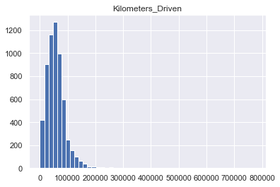

```
0
```

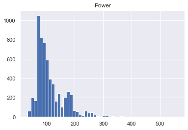

```
0
```

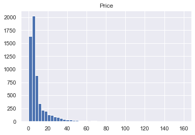

```
0
```

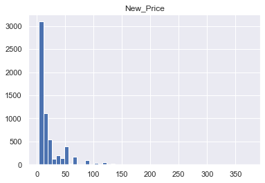

```
0
```

```python
#Kilometers_Driven, Power, New_Price and Price are rightly skewed. we can see if Log transformation can help

cols_to_log = ['Kilometers_Driven', 'Power','Price', 'New_Price']
for colname in cols_to_log:
    plt.hist(df[colname], bins=50)
    plt.title(colname)
    plt.show()
    print(np.sum(df[colname] <= 0))
```

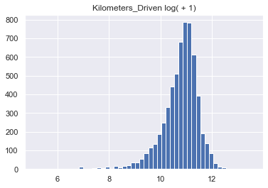

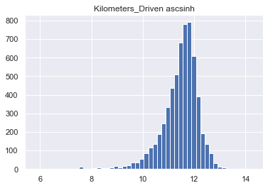

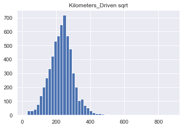

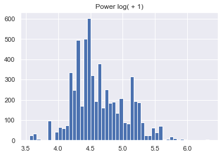

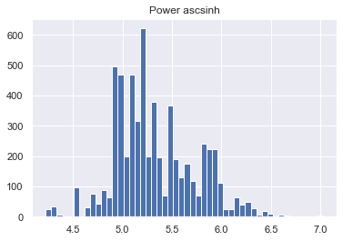

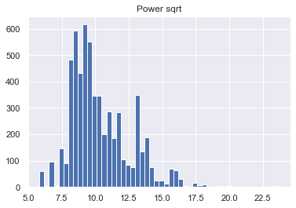

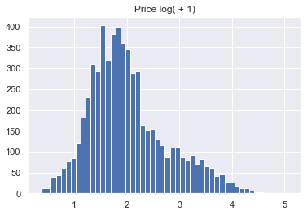

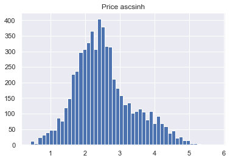

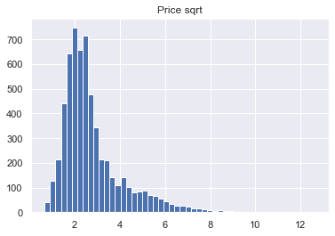

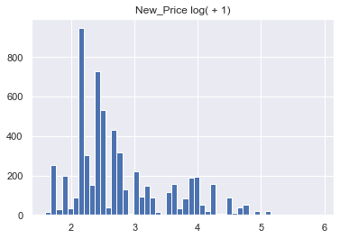

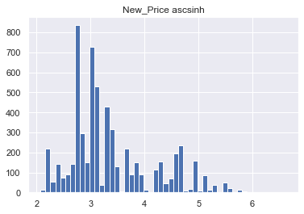

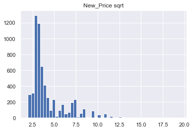

```python
#If there are zeros we cant directly take the log of these numbers. We can try log +1, ascsinh, and sqrt to see which
#works best
for colname in cols_to_log:
    plt.hist(np.log(df[colname] + 1), 50)
    plt.title(colname + ' log( + 1)')
    plt.show()
    plt.hist(np.arcsinh(df[colname]), 50)
    plt.title(colname + ' ascsinh')
    plt.show()
    plt.hist(np.sqrt(df[colname]), 50)
    plt.title(colname + ' sqrt')
    plt.show()
```

```python
#It looks like log +1 worked best for these columns so lets go ahead and update them
for colname in cols_to_log:
    df[colname + '_log'] = np.log(df[colname] + 1)
df.drop(cols_to_log, axis=1, inplace=True)
```

```python
df.head()
```

|  | Location | Year | Fuel_Type | Transmission | Owner_Type | Mileage | Engine | Seats | Kilometers_Driven_log | Power_log | Price_log | New_Price_log |
| --- | --- | --- | --- | --- | --- | --- | --- | --- | --- | --- | --- | --- |
| 0 | Mumbai | 2010 | CNG | Manual | First | 26.6 | 998 | 5 | 11.184435 | 4.080246 | 1.011601 | 1.873339 |
| 1 | Pune | 2015 | Diesel | Manual | First | 19.6 | 1582 | 5 | 10.621352 | 4.845761 | 2.602690 | 2.836737 |
| 2 | Chennai | 2011 | Petrol | Manual | First | 18.0 | 1199 | 5 | 10.736418 | 4.496471 | 1.704748 | 2.262804 |
| 3 | Chennai | 2012 | Diesel | Manual | First | 20.7 | 1248 | 7 | 11.373675 | 4.497139 | 1.945910 | 2.507157 |
| 4 | Coimbatore | 2013 | Diesel | Automatic | Second | 15.0 | 1968 | 5 | 10.613271 | 4.954418 | 2.930660 | 3.991573 |

### Standardizing continous variables

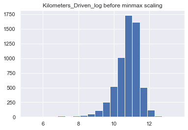

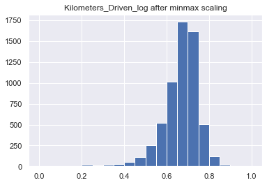

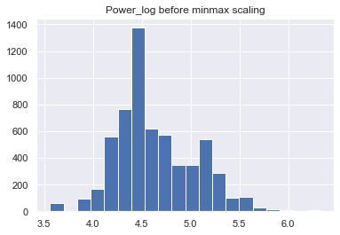

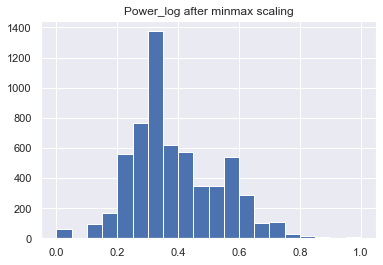

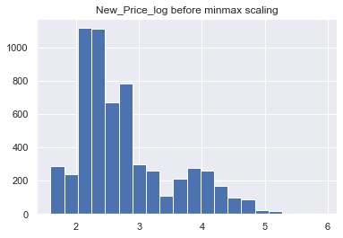

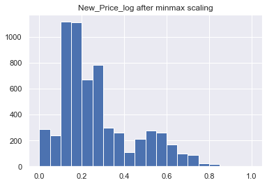

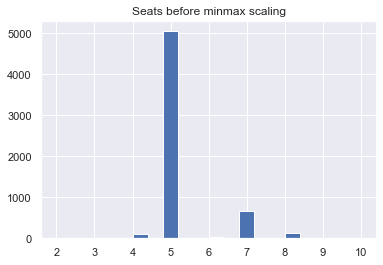

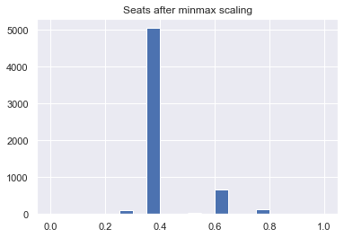

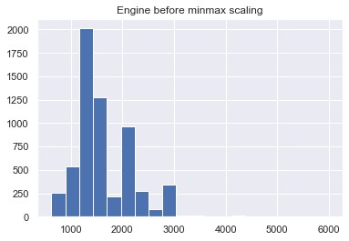

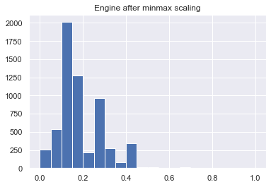

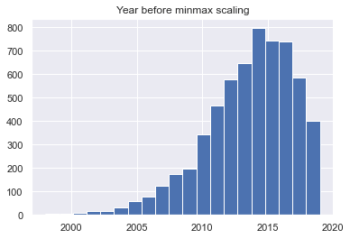

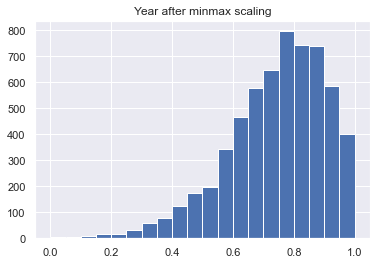

[2 more figures not shown]

```python
#loop to scale columns

std_scaler = StandardScaler()
cols_to_scale = ['Kilometers_Driven_log', 'Power_log', 'New_Price_log', 'Seats', 'Engine', 'Year', 'Mileage']
for colname in cols_to_scale:
    df[colname].hist(bins=20)
    plt.title(colname + ' before minmax scaling')
    plt.show()

    df[[colname]] = MinMaxScaler().fit_transform(
        df[[colname]]
    )

    df[colname].hist(bins=20)
    plt.title(colname + ' after minmax scaling')
    plt.show()
```

The numeric independent variables have been scaled so that we can easily compare their coeffiecients.

```python
df.head()
```

|  | Location | Year | Fuel_Type | Transmission | Owner_Type | Mileage | Engine | Seats | Kilometers_Driven_log | Power_log | Price_log | New_Price_log |
| --- | --- | --- | --- | --- | --- | --- | --- | --- | --- | --- | --- | --- |
| 0 | Mumbai | 0.571429 | CNG | Manual | First | 0.748003 | 0.069594 | 0.375 | 0.717562 | 0.187526 | 1.011601 | 0.065017 |
| 1 | Pune | 0.809524 | Diesel | Manual | First | 0.493827 | 0.178266 | 0.375 | 0.650633 | 0.464018 | 2.602690 | 0.287084 |
| 2 | Chennai | 0.619048 | Petrol | Manual | First | 0.435730 | 0.106997 | 0.375 | 0.664310 | 0.337860 | 1.704748 | 0.154791 |
| 3 | Chennai | 0.666667 | Diesel | Manual | First | 0.533769 | 0.116115 | 0.625 | 0.740056 | 0.338102 | 1.945910 | 0.211115 |
| 4 | Coimbatore | 0.714286 | Diesel | Automatic | Second | 0.326797 | 0.250093 | 0.375 | 0.649673 | 0.503263 | 2.930660 | 0.553279 |

## Model Building

### Define independent and dependent variables

```python
X = df.drop(["Price_log"], axis=1)
y = df["Price_log"]
```

### Creating dummy variables¶

```python
X = pd.get_dummies(
    X,
    columns=X.select_dtypes(include=["category"]).columns.tolist(),
    drop_first=False,
)
X.head()
```

|  | Year | Mileage | Engine | Seats | Kilometers_Driven_log | Power_log | New_Price_log | Location_Ahmedabad | Location_Bangalore | Location_Chennai | Location_Coimbatore | Location_Delhi | Location_Hyderabad | Location_Jaipur | Location_Kochi | Location_Kolkata | Location_Mumbai | Location_Pune | Fuel_Type_CNG | Fuel_Type_Diesel | Fuel_Type_LPG | Fuel_Type_Petrol | Transmission_Automatic | Transmission_Manual | Owner_Type_First | Owner_Type_Fourth & Above | Owner_Type_Second | Owner_Type_Third |
| --- | --- | --- | --- | --- | --- | --- | --- | --- | --- | --- | --- | --- | --- | --- | --- | --- | --- | --- | --- | --- | --- | --- | --- | --- | --- | --- | --- | --- |
| 0 | 0.571429 | 0.748003 | 0.069594 | 0.375 | 0.717562 | 0.187526 | 0.065017 | 0 | 0 | 0 | 0 | 0 | 0 | 0 | 0 | 0 | 1 | 0 | 1 | 0 | 0 | 0 | 0 | 1 | 1 | 0 | 0 | 0 |
| 1 | 0.809524 | 0.493827 | 0.178266 | 0.375 | 0.650633 | 0.464018 | 0.287084 | 0 | 0 | 0 | 0 | 0 | 0 | 0 | 0 | 0 | 0 | 1 | 0 | 1 | 0 | 0 | 0 | 1 | 1 | 0 | 0 | 0 |
| 2 | 0.619048 | 0.435730 | 0.106997 | 0.375 | 0.664310 | 0.337860 | 0.154791 | 0 | 0 | 1 | 0 | 0 | 0 | 0 | 0 | 0 | 0 | 0 | 0 | 0 | 0 | 1 | 0 | 1 | 1 | 0 | 0 | 0 |
| 3 | 0.666667 | 0.533769 | 0.116115 | 0.625 | 0.740056 | 0.338102 | 0.211115 | 0 | 0 | 1 | 0 | 0 | 0 | 0 | 0 | 0 | 0 | 0 | 0 | 1 | 0 | 0 | 0 | 1 | 1 | 0 | 0 | 0 |
| 4 | 0.714286 | 0.326797 | 0.250093 | 0.375 | 0.649673 | 0.503263 | 0.553279 | 0 | 0 | 0 | 1 | 0 | 0 | 0 | 0 | 0 | 0 | 0 | 0 | 1 | 0 | 0 | 1 | 0 | 0 | 0 | 1 | 0 |

```python
X.shape
```

```
(6016, 28)
```

```python
# splitting the data in 70:30 ratio for train to test data

X_train, X_test, y_train, y_test = train_test_split(
    X, y, test_size=0.30, random_state=1
)
```

### Fitting a Linear Model

```python
lin_reg_model = LinearRegression()
lin_reg_model.fit(X_train, y_train)
```

```
LinearRegression()
```

### check the coefficients and intercept of the model

```python
coef_df = pd.DataFrame(
    np.append(lin_reg_model.coef_, lin_reg_model.intercept_),
    index=X_train.columns.tolist() + ["Intercept"],
    columns=["Coefficients"],
)
coef_df.sort_values('Coefficients', ascending=False)
```

|  | Coefficients |
| --- | --- |
| Year | 1.821651 |
| New_Price_log | 1.787912 |
| Power_log | 1.307496 |
| Engine | 0.737519 |
| Location_Bangalore | 0.141781 |
| Intercept | 0.119824 |
| Location_Hyderabad | 0.117726 |
| Location_Coimbatore | 0.112019 |
| Fuel_Type_LPG | 0.110707 |
| Mileage | 0.074760 |
| Transmission_Automatic | 0.068197 |
| Owner_Type_Fourth & Above | 0.041037 |
| Location_Chennai | 0.035691 |
| Owner_Type_First | 0.022478 |
| Fuel_Type_CNG | 0.018728 |
| Seats | 0.016136 |
| Fuel_Type_Diesel | -0.005120 |
| Location_Ahmedabad | -0.006141 |
| Location_Jaipur | -0.021478 |
| Location_Kochi | -0.024701 |
| Owner_Type_Second | -0.029683 |
| Owner_Type_Third | -0.033833 |
| Location_Pune | -0.034578 |
| Location_Delhi | -0.052208 |
| Transmission_Manual | -0.068197 |
| Location_Mumbai | -0.073163 |
| Fuel_Type_Petrol | -0.124315 |
| Location_Kolkata | -0.194948 |
| Kilometers_Driven_log | -0.791128 |

### Coefficient Interpretations

Coefficients of Kilometers_Driven is negatively related to Price. This indicates that cars with higher values of kilometers_Driven have lower prices. Cars from Kolkata and Mumbai also drive a lower price. Cars that run on Petrol and cars that have a manual transmission tend to have lower prices. Cars from Delhi and Pune tend to decrease price.

However, cars that are newer have a higher Price. The New_Price of the car also increases Price. Higher Power and Engine values yield a higher price. Also cars from Bangalore, Hyderabad and Coimbatore, lead to an increase in Price. Cars that run on LPG also tend to increase price.

### Check Model Performance

```python
## Checking for multicolinearility using Variance Inflation Factor (VIF)
```

```python
vif_info = pd.DataFrame()
vif_info['VIF'] = [variance_inflation_factor(X.values, i) for i in range(X.shape[1])]
vif_info['Column'] = X.columns
vif_info.sort_values('VIF', ascending=False)
```

|  | VIF | Column |
| --- | --- | --- |
| 14 | inf | Location_Kochi |
| 15 | inf | Location_Kolkata |
| 26 | inf | Owner_Type_Second |
| 25 | inf | Owner_Type_Fourth & Above |
| 24 | inf | Owner_Type_First |
| 23 | inf | Transmission_Manual |
| 22 | inf | Transmission_Automatic |
| 21 | inf | Fuel_Type_Petrol |
| 20 | inf | Fuel_Type_LPG |
| 19 | inf | Fuel_Type_Diesel |
| 18 | inf | Fuel_Type_CNG |
| 17 | inf | Location_Pune |
| 16 | inf | Location_Mumbai |
| 27 | inf | Owner_Type_Third |
| 13 | inf | Location_Jaipur |
| 12 | inf | Location_Hyderabad |
| 11 | inf | Location_Delhi |
| 10 | inf | Location_Coimbatore |
| 9 | inf | Location_Chennai |
| 8 | inf | Location_Bangalore |
| 7 | inf | Location_Ahmedabad |
| 2 | 6.286308 | Engine |
| 5 | 6.055443 | Power_log |
| 6 | 4.783952 | New_Price_log |
| 1 | 3.329981 | Mileage |
| 0 | 2.126623 | Year |
| 3 | 1.751276 | Seats |
| 4 | 1.721020 | Kilometers_Driven_log |

```python
# Using a function to compute adjusted R-squared
def adj_r2_score(predictors, targets, predictions):
    r2 = r2_score(targets, predictions)
    n = predictors.shape[0]
    k = predictors.shape[1]
    return 1 - ((1 - r2) * (n - 1) / (n - k - 1))


# function to compute MAPE
def mape_score(targets, predictions):
    return np.mean(np.abs(targets - predictions) / targets) * 100


# function to compute different metrics to check performance of a regression model
def model_performance_regression(model, predictors, target):
    """
    Function to compute different metrics to check regression model performance

    model: regressor
    predictors: independent variables
    target: dependent variable
    """

    # predicting using the independent variables
    pred = model.predict(predictors)

    r2 = r2_score(target, pred)  # to compute R-squared
    adjr2 = adj_r2_score(predictors, target, pred)  # to compute adjusted R-squared
    rmse = np.sqrt(mean_squared_error(target, pred))  # to compute RMSE
    mae = mean_absolute_error(target, pred)  # to compute MAE
    mape = mape_score(target, pred)  # to compute MAPE

    # creating a dataframe of metrics
    df_perf = pd.DataFrame(
        {
            "RMSE": rmse,
            "MAE": mae,
            "R-squared": r2,
            "Adj. R-squared": adjr2,
            "MAPE": mape,
        },
        index=[0],
    )

    return df_perf
```

```python
# Checking model performance on train set
print("Training Performance\n")
lin_reg_model_train_perf = model_performance_regression(lin_reg_model, X_train, y_train)
lin_reg_model_train_perf
```

```
Training Performance
```

|  | RMSE | MAE | R-squared | Adj. R-squared | MAPE |
| --- | --- | --- | --- | --- | --- |
| 0 | 0.216003 | 0.157947 | 0.917482 | 0.91693 | 9.510798 |

```python
# Checking model performance on test set
print("Test Performance\n")
lin_reg_model_test_perf = model_performance_regression(lin_reg_model, X_test, y_test)
lin_reg_model_test_perf
```

```
Test Performance
```

|  | RMSE | MAE | R-squared | Adj. R-squared | MAPE |
| --- | --- | --- | --- | --- | --- |
| 0 | 0.205123 | 0.153999 | 0.922703 | 0.921484 | 9.223453 |

Observations

The train and test R2 are 0.92 and also 0.92 for train, indicating that the model explains 92% of the total variation in the train and test sets respectively. The adjusted R2 is also 0.92 and both scores are comparable.

RMSE values 0f 0.2 on the train and test sets are also comparable.

This shows that the model is not overfitting.

MAE indicates that our current model is able to predict price within a mean error of 0.16

## Forward Feature Selection using SequentialFeatureSelector

```python
# Run following code if mlxtend library is not previously installed
#!pip install mlxtend
```

```python
from mlxtend.feature_selection import SequentialFeatureSelector as SFS

reg = LinearRegression()

# Build step forward feature selection
sfs = SFS(
    reg,
    k_features=X_train.shape[1],
    forward=True,  # k_features denotes the number of features to select
    floating=False,
    scoring="r2",
    n_jobs=-1,  # n_jobs=-1 means all processor cores will be used
    verbose=2,
    cv=5,
)

# Perform SFFS
sfs = sfs.fit(X_train, y_train)
```

[output not shown]

[output cut: 57 more lines]

[output not shown]

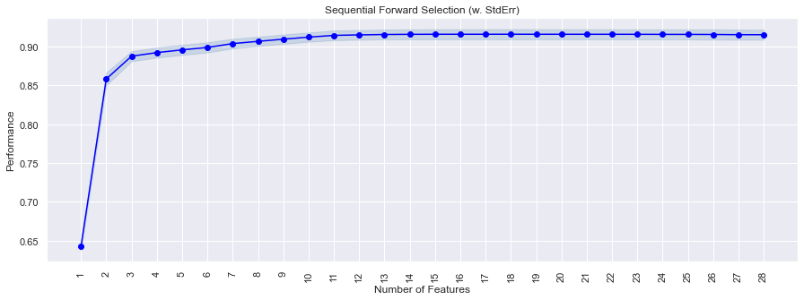

```python
# to plot the performance with addition of each feature
from mlxtend.plotting import plot_sequential_feature_selection as plot_sfs

fig1 = plot_sfs(sfs.get_metric_dict(), kind="std_err", figsize=(15, 5))
plt.title("Sequential Forward Selection (w. StdErr)")
plt.xticks(rotation=90)
plt.show()
```

We can see that performance increases till the 12th feature and then slowly becomes constant With 28 features, we are getting an adjusted R2 of around 0.92 With 10 features, we are also getting an adjusted around R2 of 0.92 The increase in adjusted R2 is not very significant as we are getting the same values with a less complex model. So we'll use 12 features only to build our model.

```python
reg = LinearRegression()

# Build step forward feature selection
#setting maximum features to 10
sfs = SFS(
    reg,
    k_features=12,
    forward=True,
    floating=False,
    scoring="r2",
    n_jobs=-1,
    verbose=2,
    cv=5,
)

# Perform SFFS
sfs = sfs.fit(X_train, y_train)
```

[output not shown]